# Part I - Data Exploration of Loan Data from Prosper

#### **Question 3**: What is the most preferred loan duration (`Term`) among borrowers based on the dataset?

```python
duration_count = loan_df.Term.value_counts()
duration_count
```

```
36    87753
60    24545
12     1614
Name: Term, dtype: int64
```

##### **Visualisation**

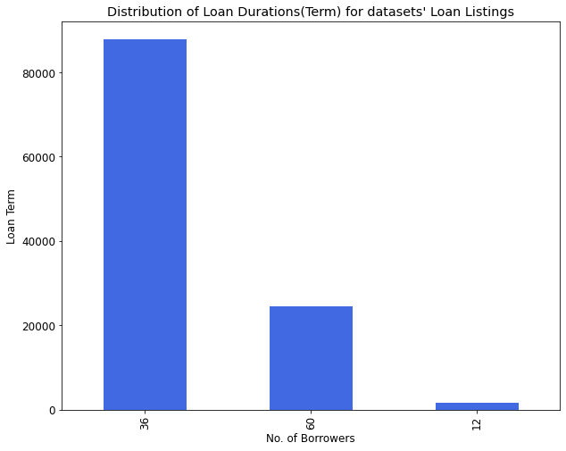

```python
# Plotting Distribution of Loan Duration(Term) for Loan Borrowers
plt.figure(figsize=[10, 8])
# pltbar(data=loan_df, x='Term', y='', color='royalblue');
duration_count.plot.bar(color='royalblue')
plt.title("Distribution of Loan Durations(Term) for datasets' Loan Listings")
plt.xlabel('No. of Borrowers')
plt.ylabel('Loan Term');
```

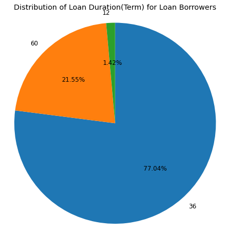

```python
# Use the same pokemon dataset
sorted_times = loan_df['Term'].value_counts()
plt.figure(figsize=[10, 8])
plt.pie(sorted_times, labels = sorted_times.index, startangle = 90, counterclock = False, autopct='%1.2f%%');
plt.title('Distribution of Loan Duration(Term) for Loan Borrowers')
plt.axis('square');
plt.show()
```

##### **Observation**

A vast majority of Loan Listings in the dataset had a set loan period (`Term`) of **3 Years**(36 Months) with **87753(77.04%) loan listings** followed by **5 Year** (60 Month) loan spells with **24545(21.55%)** and lastly **1 Year** (12 Month) loan spells has **1614(1.42%)** Loan Listings. Most Prosper Loanees perfer mid-long term loans.

#### **Question 4**: What is the distribution of `StatedMonthlyIncome` for Prosper's Loan Borrowers?

```python
loan_df.StatedMonthlyIncome.describe()
```

```
count    1.139120e+05
mean     5.606973e+03
std      7.478338e+03
min      0.000000e+00
25%      3.200000e+03
50%      4.666667e+03
75%      6.817083e+03
max      1.750003e+06
Name: StatedMonthlyIncome, dtype: float64
```

```python
loan_df.StatedMonthlyIncome.isnull().sum()
```

```
0
```

##### **Visualisation**

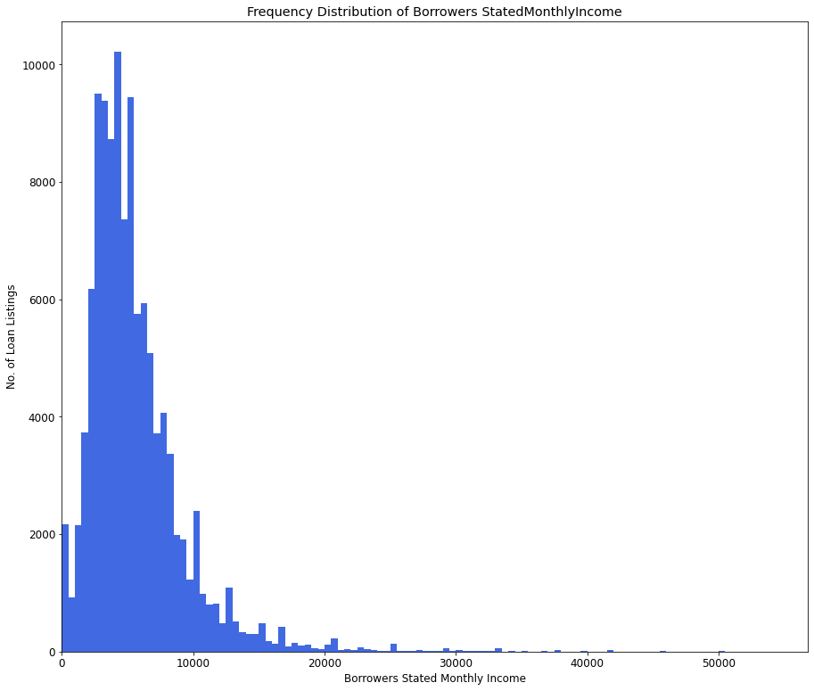

```python
# Pot frequency disribution of BorrowerAPR feature
bbins = np.arange(0, loan_df['StatedMonthlyIncome'].max()+500, 500)
# bbins = np.arange(0, 6.817083e+03+100, 00)
plt.figure(figsize=[15, 13])
plt.hist(data=loan_df, x="StatedMonthlyIncome", color='royalblue', bins=bbins);
plt.title('Frequency Distribution of Borrowers StatedMonthlyIncome')
plt.xlim(0, 6.817083e+03+50000)
plt.xlabel('Borrowers Stated Monthly Income')
plt.ylabel('No. of Loan Listings');
```

##### **Observation**

Most Loan Borrowers earn less than 10000 with majority of Borrowers earning between 3000 and 6000 as Monthly earnings. The most outrageous borrower earns about a million units() with 1,750,003 units.

#### **Question 5**: What are the most dominant `Loan Statuses` for Prosper's Loan Listings?

```python
loan_status_counts = loan_df.LoanStatus.value_counts()
loan_status_counts
```

```
Current                   56576
Completed                 38049
Chargedoff                11992
Defaulted                  5018
Past Due (1-15 days)        806
Past Due (31-60 days)       363
Past Due (61-90 days)       313
Past Due (91-120 days)      304
Past Due (16-30 days)       265
FinalPaymentInProgress      205
Past Due (>120 days)         16
Cancelled                     5
Name: LoanStatus, dtype: int64
```

##### **Visualisation**

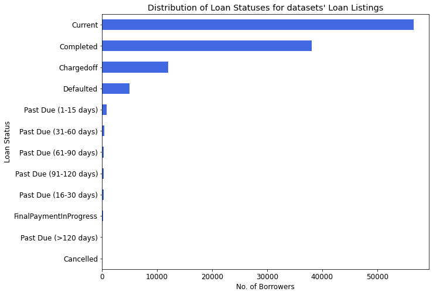

```python
# Plotting Distribution of Loan Statuses for Loan Borrowers
plt.figure(figsize=[10, 8])
# plt.bar(data=loan_df, x='Term', y='', color='royalblue');
loan_status_counts.plot.barh(color='royalblue').invert_yaxis()
plt.title("Distribution of Loan Statuses for datasets' Loan Listings")
plt.xlabel('No. of Borrowers')
plt.ylabel('Loan Status');
```

##### **Observation**

Most of the Loan Listings, were (**Current Loans with 56576 listings**) followed closely by **38049 Completed Loan listings** that were fully paid off. **11992 Loan Listings** were Charged Off meaning that the lendor(Propser) considered these loans uncollectable for various reasons such as an agreement not to collect an amount, an account being many months past due, or failure to perform a settlement agreement. There were **5018 Loan Defaulters** who did not pay their Loans.

#### **Question 6**: What is the distribution of `IncomeRange` for Prospers' borrowers?

```python
income_ranges = loan_df.IncomeRange.value_counts()
income_ranges
```

```
$25,000-49,999    32192
$50,000-74,999    31050
$100,000+         17337
$75,000-99,999    16916
Not displayed      7716
$1-24,999          7274
Not employed        806
$0                  621
Name: IncomeRange, dtype: int64
```

##### **Visualisation**

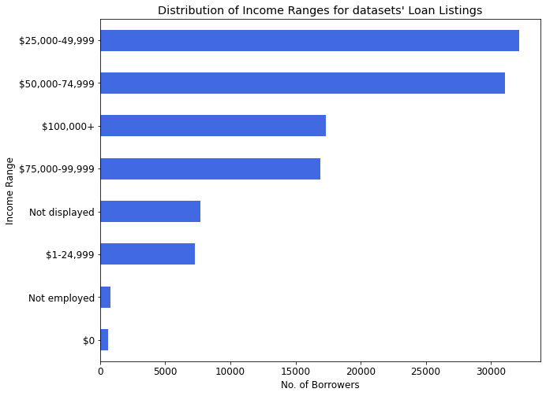

```python
# Plotting Distribution of Income Ranges for Loan Borrowers
plt.figure(figsize=[10, 8])
# pltbar(data=loan_df, x='Term', y='', color='royalblue');
income_ranges.plot.barh(color='royalblue').invert_yaxis()
plt.title("Distribution of Income Ranges for datasets' Loan Listings")
plt.xlabel('No. of Borrowers')
plt.ylabel('Income Range');
```

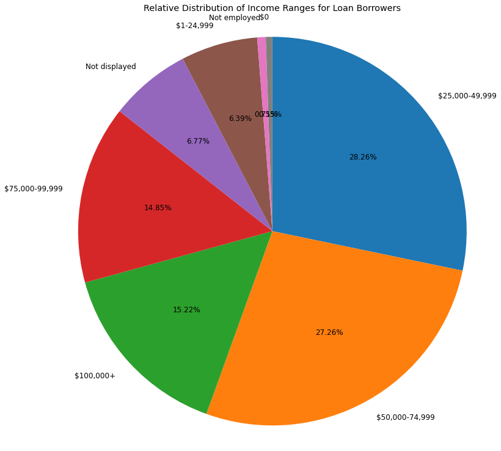

```python
# Plot Pie Chart of Relative Borrower Income Range Distribution
plt.figure(figsize=[15, 13])
plt.pie(income_ranges, labels = income_ranges.index, startangle = 90, counterclock = False, autopct='%1.2f%%');
plt.title('Relative Distribution of Income Ranges for Loan Borrowers')
plt.axis('square');
plt.show()
```

##### **Observation**

**28.26% (32192)** borrowers earn between **$25,000-49,999** and make up the majority of loan listings in this dataset. Borrowers earning between **$50,000-74,999** making up **27.26%(31050)** of available loan listings and those earning **+$100,000** making up **15.22%(17337)** and those earning **$75,000-99,999** making up **14.85%(16916)**. Less tha 1% of borrowers were unemployed at the time of the loan listing.

### Discuss the distribution(s) of your variable(s) of interest. Were there any unusual points? Did you need to perform any transformations?

`StatedMonthlyIncome` was a feature of interest as it was necessary to assess the most common income range for most loan borrowers as it offers insight into how much most of Prosper's Loan Borrowers earn which could drive business decisions on Prosper's Loan offerings. This feature's distribution is right skewed with its peaks appearing towards the left of the graph area. The most unusual data point for this feature was the Loan Borrower who earns as much as 1,750,003 units. This is quite an interesting borrower as most borrowers earn less than 10,000 units with the majority earning between 3000 and 6000 units.

`Term` is also a feature of interest as it shows the most preferred loan repayment durations amongst borrowers at Prosper. 77% of borrowers prefer 3 Year Loans with 22% taking up 5 Year loans and 1% taking 1 Year Loans.

`EmploymentStatus` was another interesting variable to assess as it was necessary to understand the most common EmploymentStatus amongst Loan Borrowers at Prosper.

### Of the features you investigated, were there any unusual distributions? Did you perform any operations on the data to tidy, adjust, or change the form of the data? If so, why did you do this?

`StatedMonthlyIncome` had a oan Borrower who earns an outrageous 1,750,003 units while most borrowers earned less than 10,000 units.This loan listing would be interesting to look at in order to understand the nature of the loan transacted.

`BorrowerAPR` & `StatedMonthlyIncome` were transformed by being put into appropriate bins ranging from their maximum to minimum+k(constant) for making more meaningful histogram distributions.

## Bivariate Exploration

```python
loan_df.info()
```

```
<class 'pandas.core.frame.DataFrame'>
Int64Index: 113912 entries, 0 to 113936
Data columns (total 17 columns):
 #   Column               Non-Null Count   Dtype
---  ------               --------------   -----
 0   LoanKey              113912 non-null  object
 1   CreditGrade          28928 non-null   object
 2   IncomeRange          113912 non-null  object
 3   StatedMonthlyIncome  113912 non-null  float64
 4   LoanOriginalAmount   113912 non-null  int64
 5   Term                 113912 non-null  int64
 6   LoanStatus           113912 non-null  object
 7   BorrowerAPR          113912 non-null  float64
 8   BorrowerRate         113912 non-null  float64
 9   ProsperScore         84853 non-null   float64
 10  ProsperRating        84853 non-null   float64
 11  TotalProsperLoans    22085 non-null   float64
 12  EmploymentStatus     111682 non-null  object
 13  DebtToIncomeRatio    105358 non-null  float64
 14  EstimatedReturn      84853 non-null   float64
 15  EstimatedLoss        84853 non-null   float64
 16  Investors            113912 non-null  int64
dtypes: float64(9), int64(3), object(5)
memory usage: 19.7+ MB
```

#### **Question 7**: Is there a relationship that exists between Loan Borrowers' `BorrowerAPR` and the `BorrowerRate`?

##### **Visualisation**

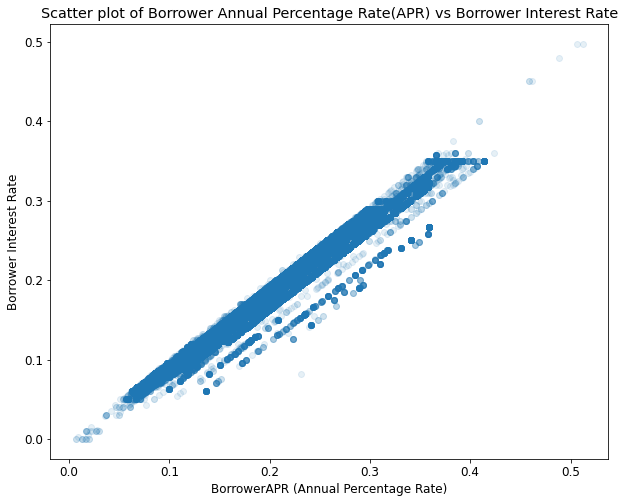

```python
# Scatter plot of Borrower APR vs Borrower Rate
plt.figure(figsize=[10, 8])
plt.scatter(data = loan_df, x = 'BorrowerAPR', y = 'BorrowerRate', alpha=1/9)
plt.title("Scatter plot of Borrower Annual Percentage Rate(APR) vs Borrower Interest Rate")
plt.ylabel('Borrower Interest Rate')
plt.xlabel('BorrowerAPR (Annual Percentage Rate)');
```

##### **Observation**

The general trend observed while comparing the `BorrowerAPR` & `BorrowerRate` quantitative features depicted a possitive correlation between the two variables. The datapoints are closely clustered together while making a straight line(slope) from near origin point (0,0) as values of datapoints continually increasing as x & y increase. This slope illustrates a strong positive correlation between a loan's Borrower Interest Rate and Borrower Annual Percentage Rate.

#### **Question 8**: Does a Loan Borrower's Interest Rate have any impact on the Loan's Estimated Returns?

##### **Visualisation**

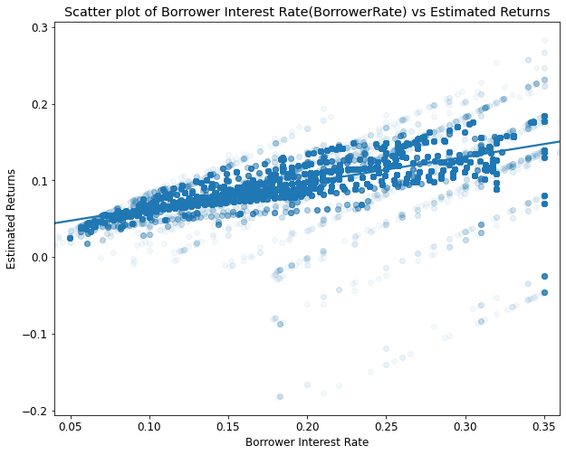

```python
# Scatter plot of Borrower APR vs Borrower Rate
plt.figure(figsize=[10, 8])
sb.regplot(data = loan_df, x = 'BorrowerRate', y = 'EstimatedReturn', scatter_kws={'alpha':1/20});
plt.title("Scatter plot of Borrower Interest Rate(BorrowerRate) vs Estimated Returns")
plt.ylabel('Estimated Returns')
plt.xlabel('Borrower Interest Rate');
```

##### **Observation**

The variables `BorrowerRate` & `EstimatedReturn` also depict a positive correlation as data points are closely clustered together creating a slope that increases as values of the x and y axes increase. A line of best fit has also been added to this visualisation to show the general trend of the data points which is generally positive. This means the higher a Loan's Borrower Interest Rate, the higher the Estimated Returns.

#### **Question 9**: What are the pairwise correlations for the numeric features of interest in this dataset?

i.e `BorrowerAPR, EstimatedReturn, EstimatedLoss, BorrowerRate,StatedMonthlyIncome, LoanOriginalAmount, PropserScore, TotalProsperLoans, DebtToIncomeratio, Term, Investors`

```python
numeric_vars = ['StatedMonthlyIncome', 'LoanOriginalAmount', 'Term', 'BorrowerAPR', 'BorrowerRate', 'ProsperScore', 'TotalProsperLoans', 'DebtToIncomeRatio', 'EstimatedReturn', 'EstimatedLoss', 'Investors']
loan_df[numeric_vars].corr()
```

|  | StatedMonthlyIncome | LoanOriginalAmount | Term | BorrowerAPR | BorrowerRate | ProsperScore | TotalProsperLoans | DebtToIncomeRatio | EstimatedReturn | EstimatedLoss | Investors |
| --- | --- | --- | --- | --- | --- | --- | --- | --- | --- | --- | --- |
| StatedMonthlyIncome | 1.000000 | 0.201431 | 0.028549 | -0.082338 | -0.088859 | 0.083757 | 0.027344 | -0.122594 | -0.075013 | -0.089259 | 0.076361 |
| LoanOriginalAmount | 0.201431 | 1.000000 | 0.338891 | -0.322887 | -0.329292 | 0.266293 | 0.066521 | 0.010039 | -0.286118 | -0.429890 | 0.380029 |
| Term | 0.028549 | 0.338891 | 1.000000 | -0.011183 | 0.019953 | 0.028947 | 0.070311 | -0.014710 | 0.152505 | -0.107140 | -0.045214 |
| BorrowerAPR | -0.082338 | -0.322887 | -0.011183 | 1.000000 | 0.989824 | -0.668287 | -0.041467 | 0.056327 | 0.794275 | 0.949538 | -0.307606 |
| BorrowerRate | -0.088859 | -0.329292 | 0.019953 | 0.989824 | 1.000000 | -0.649736 | -0.049270 | 0.062822 | 0.817670 | 0.945297 | -0.274515 |
| ProsperScore | 0.083757 | 0.266293 | 0.028947 | -0.668287 | -0.649736 | 1.000000 | 0.070522 | -0.145336 | -0.383211 | -0.673727 | 0.320594 |
| TotalProsperLoans | 0.027344 | 0.066521 | 0.070311 | -0.041467 | -0.049270 | 0.070522 | 1.000000 | 0.002098 | -0.065137 | -0.040204 | -0.035074 |
| DebtToIncomeRatio | -0.122594 | 0.010039 | -0.014710 | 0.056327 | 0.062822 | -0.145336 | 0.002098 | 1.000000 | 0.087236 | 0.126116 | 0.004034 |
| EstimatedReturn | -0.075013 | -0.286118 | 0.152505 | 0.794275 | 0.817670 | -0.383211 | -0.065137 | 0.087236 | 1.000000 | 0.591056 | -0.092337 |
| EstimatedLoss | -0.089259 | -0.429890 | -0.107140 | 0.949538 | 0.945297 | -0.673727 | -0.040204 | 0.126116 | 0.591056 | 1.000000 | -0.275501 |
| Investors | 0.076361 | 0.380029 | -0.045214 | -0.307606 | -0.274515 | 0.320594 | -0.035074 | 0.004034 | -0.092337 | -0.275501 | 1.000000 |

##### **Visualisation**

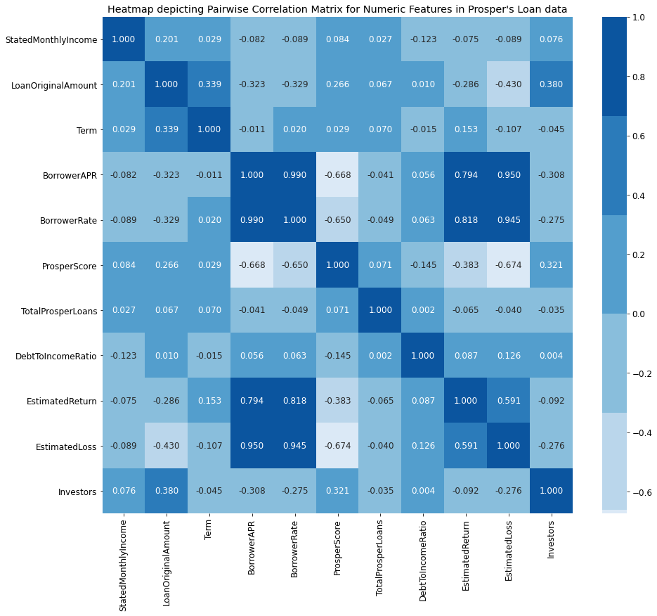

```python
# Plotting Heatmap for Pairwise Correlation Matrix for Numeric Features of Loan Dataset
plt.figure(figsize = [15, 13])
plt.title("Heatmap depicting Pairwise Correlation Matrix for Numeric Features in Prosper's Loan data")
colormap = sb.color_palette("Blues")
sb.heatmap(loan_df[numeric_vars].corr(), annot = True, fmt = '.3f',
           cmap = colormap, center = 0);
```

##### **Observation**

From the above heatmap canvas, there were strong positive correlations between the following feature-pairs:

- `BorrowerAPR` & `BorrowerRate` = 0.990
- `BorrowerAPR` & `EstimatedLoss` = 0.950
- `BorrowerRate` & `EstimatedLoss` = 0.0.945
- `BorrowerRate` & `EstimatedReturn` = 0.818
- `EstimatedReturn` & `EstimatedLoss` = 0.591

As for feature-pairs with negative correlations, they ones showing the strongest negative correlations were;

- `BorrowerAPR` & `ProsperScore` = -0.668
- `EstimatedLoss` & `ProsperScore` = -0.674
- `BorrowerRate` & `ProsperScore` = -0.650